# STAT 413/613 Homework: Tidy Text

Ifebunandu Jerome Okeke

2021-04-26

# Instructions

1. Clone this homework repo to your homework directory as a new repo.
2. Rename the starter file under the analysis directory as `hw_01_yourname.Rmd` and use it for your solutions.
3. Modify the “author” field in the YAML header.
4. Stage and Commit R Markdown and HTML files (no PDF files).
5. **Push both .Rmd and HTML files to GitHub**.
- Make sure you have knitted to HTML prior to staging, committing, and pushing your final submission.
6. **Commit each time you answer a part of question, e.g. 1.1**
7. **Push to GitHub after each major question**
8. When complete, submit a response in Canvas
- Only include necessary code to answer the questions.
- Most of the functions you use should be from the tidyverse.
- Unnecessary Base R or other packages not covered in class will result in point deductions.
- Use Pull requests and or email to ask me any questions. If you email, please ensure your most recent code is pushed to GitHub.

# 1 Sentiment Analysis

1. Download the following two works from the early 20<sup>th</sup> century from Project Gutenberg:
- Upton Sinclair: “*The Jungle*” (1906)
- W.E.B. Du Bois: “*The Quest of the Silver Fleece*” (1911)

```r
# Load library

library(tidyverse)
library(tidytext)
library(gutenbergr)
```

## 1.1

## 1.2

```r
Sinclair <- gutenberg_works(title == "The Jungle") %>%

  gutenberg_download()
```

```
## Determining mirror for Project Gutenberg from http://www.gutenberg.org/robot/harvest
```

```
## Using mirror http://aleph.gutenberg.org
```

## 1.3

## 1.4

```r
Duboise <- gutenberg_works(str_detect(title, "The Quest of the Silver Fleece")) %>%

  gutenberg_download()
```

## 1.5

## 1.6

2. Write a function `to take an argument of a downloaded book tibble and return it in tidy text format.
- The function must add line and chapter numbers as variables
- The function must unnest tokens at the word level
- The function must remove any Project Gutenberg formatting so only the words remain
- The function must remove any stop_words and filter out any `NA`s
- The function must remove any front matter (words before Chapter 1)
- The function can consider the unique nature of the front matter but cannot consider exactly how many chapters are in each book based on looking at the data i.e., no math based on knowing the number of chapters.

## 1.7

## 1.8

```r
book_tidy <- function(x) {
  stopifnot(is.tibble(x),
            is.integer(x[[1]]),
            is.character(x[[2]]))
  if (x$text %>% has_element("_Contents_") == TRUE) {
    if (x$text %>% has_element("_Note_") == TRUE) {
    x %>%
      filter(text != "_Contents_" & text != "_Note_") %>%
      mutate(linenumber = row_number(),
             chapter = cumsum(str_detect(text,
                                         regex("^_[[:alpha:]]+_$|^_[[:alpha:]]+-[[:alpha:]]+_$",
                                               ignore_case = FALSE)))) %>%
      unnest_tokens(word, text) %>%
      mutate(word = str_extract(word, "[a-z']+")) %>%
      anti_join(stop_words, by = "word") %>%
      filter(chapter > 0,
             !is.na(word))
    }
  }
  else {
    x %>%
      mutate(linenumber = row_number(),
             chapter = cumsum(str_detect(text,
                                         regex("^chapter [\\divxlc]",
                                               ignore_case = TRUE)))) %>%
      unnest_tokens(word, text) %>%
      mutate(word = str_extract(word, "[a-z']+")) %>%
      anti_join(stop_words, by = "word") %>%
      filter(chapter > 0,
             !is.na(word))
  }
}

book_tidy(Sinclair)
```

```
## # A tibble: 47,828 x 4
##    gutenberg_id linenumber chapter word
##           <int>      <int>   <int> <chr>
##  1          140         52       1 chapter
##  2          140         55       1 ceremony
##  3          140         55       1 carriages
##  4          140         56       1 arrive
##  5          140         56       1 crowd
##  6          140         56       1 owing
##  7          140         57       1 exuberance
##  8          140         57       1 marija
##  9          140         57       1 berczynskas
## 10          140         57       1 occasion
## # ... with 47,818 more rows
```

```r
book_tidy(Duboise)
```

```
## # A tibble: 41,606 x 4
##    gutenberg_id linenumber chapter word
##           <int>      <int>   <int> <chr>
##  1        15265        142       1 dreams
##  2        15265        145       1 night
##  3        15265        145       1 fell
##  4        15265        145       1 red
##  5        15265        145       1 waters
##  6        15265        145       1 swamp
##  7        15265        145       1 grew
##  8        15265        145       1 sinister
##  9        15265        145       1 sullen
## 10        15265        146       1 tall
## # ... with 41,596 more rows
```

## 1.9

## 1.10

3. Use the function from step 2
- Tidy each book and then add `book` and `author` as variables and save each tibble to a new variable. How many rows are in each book?

```r
book_tidy(Sinclair) -> sinclair

book_tidy(Duboise) -> Duboise
```

### 1.10.1

### 1.10.2

### 1.10.3

```r
sinclair_new <- sinclair %>%
  mutate(book = gutenberg_works(title == "The Jungle")[[2]],
         author = gutenberg_works(title == "The Jungle")[[3]])

 sinclair_new
```

```
## # A tibble: 47,828 x 6
##    gutenberg_id linenumber chapter word        book       author
##           <int>      <int>   <int> <chr>       <chr>      <chr>
##  1          140         52       1 chapter     The Jungle Sinclair, Upton
##  2          140         55       1 ceremony    The Jungle Sinclair, Upton
##  3          140         55       1 carriages   The Jungle Sinclair, Upton
##  4          140         56       1 arrive      The Jungle Sinclair, Upton
##  5          140         56       1 crowd       The Jungle Sinclair, Upton
##  6          140         56       1 owing       The Jungle Sinclair, Upton
##  7          140         57       1 exuberance  The Jungle Sinclair, Upton
##  8          140         57       1 marija      The Jungle Sinclair, Upton
##  9          140         57       1 berczynskas The Jungle Sinclair, Upton
## 10          140         57       1 occasion    The Jungle Sinclair, Upton
## # ... with 47,818 more rows
```

```r
Duboise_new <- Duboise %>%
  mutate(book = gutenberg_works(title == "The Quest of the Silver Fleece: A Novel")[[2]],
         author = gutenberg_works(title == "The Quest of the Silver Fleece: A Novel")[[3]])

Duboise_new
```

```
## # A tibble: 41,606 x 6
##    gutenberg_id linenumber chapter word    book              author
##           <int>      <int>   <int> <chr>   <chr>             <chr>
##  1        15265        142       1 dreams  The Quest of the~ Du Bois, W. E. B. ~
##  2        15265        145       1 night   The Quest of the~ Du Bois, W. E. B. ~
##  3        15265        145       1 fell    The Quest of the~ Du Bois, W. E. B. ~
##  4        15265        145       1 red     The Quest of the~ Du Bois, W. E. B. ~
##  5        15265        145       1 waters  The Quest of the~ Du Bois, W. E. B. ~
##  6        15265        145       1 swamp   The Quest of the~ Du Bois, W. E. B. ~
##  7        15265        145       1 grew    The Quest of the~ Du Bois, W. E. B. ~
##  8        15265        145       1 sinist~ The Quest of the~ Du Bois, W. E. B. ~
##  9        15265        145       1 sullen  The Quest of the~ Du Bois, W. E. B. ~
## 10        15265        146       1 tall    The Quest of the~ Du Bois, W. E. B. ~
## # ... with 41,596 more rows
```

```r
comb_sinclair_Dubiose <- sinclair_new %>%
  full_join(Duboise_new, by = c("gutenberg_id", "linenumber", "chapter", "word", "book", "author"))

comb_sinclair_Dubiose
```

```
## # A tibble: 89,434 x 6
##    gutenberg_id linenumber chapter word        book       author
##           <int>      <int>   <int> <chr>       <chr>      <chr>
##  1          140         52       1 chapter     The Jungle Sinclair, Upton
##  2          140         55       1 ceremony    The Jungle Sinclair, Upton
##  3          140         55       1 carriages   The Jungle Sinclair, Upton
##  4          140         56       1 arrive      The Jungle Sinclair, Upton
##  5          140         56       1 crowd       The Jungle Sinclair, Upton
##  6          140         56       1 owing       The Jungle Sinclair, Upton
##  7          140         57       1 exuberance  The Jungle Sinclair, Upton
##  8          140         57       1 marija      The Jungle Sinclair, Upton
##  9          140         57       1 berczynskas The Jungle Sinclair, Upton
## 10          140         57       1 occasion    The Jungle Sinclair, Upton
## # ... with 89,424 more rows
```

5. Measure the net sentiment using bing for each block of 50 lines
- Plot the sentiment for each book in an appropriate faceted plot - either line or column.
- Be sure to remove the legend.
- Save the plot to a variable
- Interpret the plots for each book and compare them.

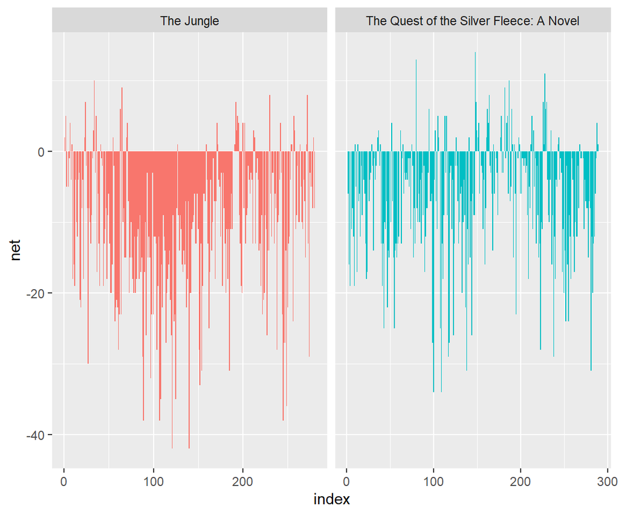

```r
comb_sinclair_Dubiose %>%
  inner_join(get_sentiments("bing"), by = "word") %>%
  count(book, index = linenumber %/% 50, sentiment) %>%
  pivot_wider(names_from = sentiment, values_from = n, values_fill = list(n=0)) %>%
  mutate(net = positive - negative) ->
  comb_sinclair_Dubiose_sentiment

comb_sinclair_Dubiose_sentiment %>%
  ggplot(aes(index, net, fill = book)) +
  geom_col(show.legend = FALSE) +
  facet_wrap(~book, ncol = 2, scales = "free_x")
```

**-** Looking at the plot, it reveals that the comment on both books are largely negative. **-** The Quest of the silver fleece has more positive comments than the jungle **-** Both books have a large negative comments than positive with jungle exhibiting a slightly higher negative comment than the Quest of the silver fleece

6. Measure the total for each nrc sentiment in each block of 500 lines and then,
- Filter out the “positive” and “negative” and save to a new variable. You should have 464 observations.
- Plot the count of the sentiments for each block in each book in an appropriate faceted plot with the books in two columns and the sentiments in 8 rows.
- Be sure to remove the legend.
- Interpret the plots for each book and then compare them.
- Why did the values drop off so suddenly at the end?

## 1.11

```r
comb_sinclair_Dubiose %>%
  inner_join(get_sentiments("nrc"), by = "word") %>%
  count(book, index = linenumber %/% 500, sentiment) %>%
  filter(sentiment != "positive",
         sentiment != "negative") ->

  sinclair_Dubiose_nrc
```

## 1.12

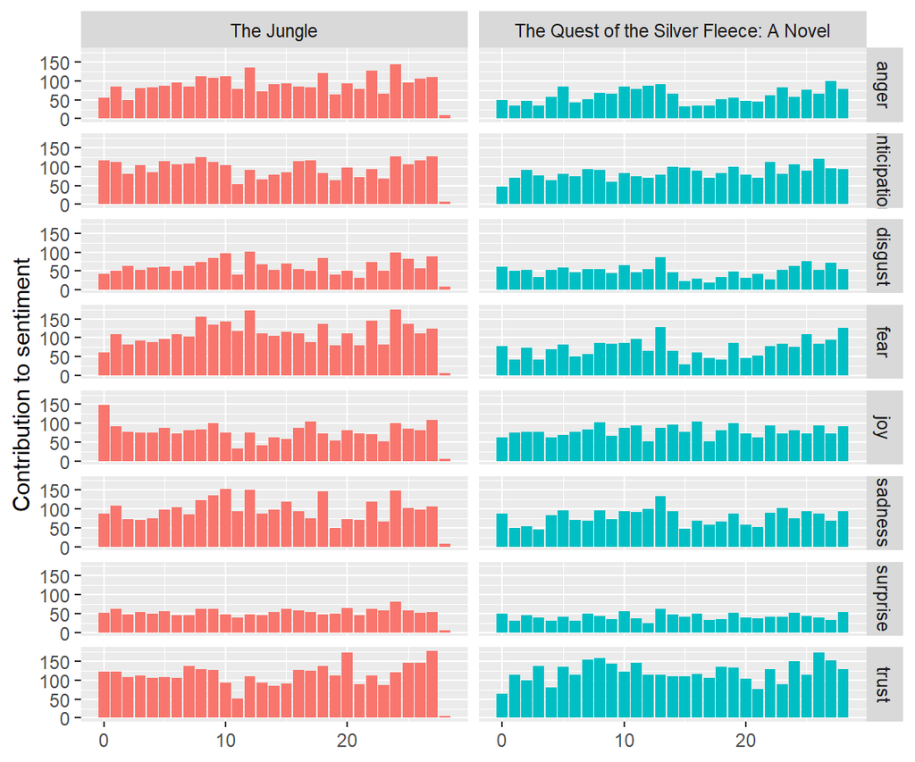

```r
sinclair_Dubiose_nrc %>%
  ggplot(aes(x = index, y = n, fill = book)) +
  geom_col(show.legend = FALSE) +
  facet_grid(rows = vars(sentiment), cols = vars(book), scales = "free_x") +
  labs(y = "Contribution to sentiment", x = NULL)
```

7. Using bing, create a new data frame with the counts of the positive and negative sentiment words for each book.
- Show the “top 20” most frequent words across both books along with their book, sentiment, and count, in descending order by count.
- What are the positive words in the list of “top 20”?

```r
comb_sinclair_Dubiose %>%
  group_by(book) %>%
  inner_join(get_sentiments("bing"), by = "word") %>%
  count(word, sentiment, sort = TRUE) %>%
  arrange() %>%
  ungroup() %>%
  head(20) -> comb_sclr_Dub_top_20

comb_sclr_Dub_top_20 %>%

  filter(sentiment == "positive")
```

```
## # A tibble: 4 x 4
##   book                                    word   sentiment     n
##   <chr>                                   <chr>  <chr>     <int>
## 1 The Quest of the Silver Fleece: A Novel love   positive     54
## 2 The Quest of the Silver Fleece: A Novel mighty positive     48
## 3 The Jungle                              free   positive     44
## 4 The Quest of the Silver Fleece: A Novel silent positive     43
```

```r
  comb_sclr_Dub_top_20
```

```
## # A tibble: 20 x 4
##    book                                    word    sentiment     n
##    <chr>                                   <chr>   <chr>     <int>
##  1 The Quest of the Silver Fleece: A Novel miss    negative    467
##  2 The Quest of the Silver Fleece: A Novel slowly  negative    124
##  3 The Quest of the Silver Fleece: A Novel dark    negative     96
##  4 The Jungle                              poor    negative     80
##  5 The Jungle                              cold    negative     79
##  6 The Jungle                              hard    negative     61
##  7 The Jungle                              lost    negative     61
##  8 The Jungle                              wild    negative     55
##  9 The Quest of the Silver Fleece: A Novel love    positive     54
## 10 The Jungle                              fell    negative     51
## 11 The Quest of the Silver Fleece: A Novel fell    negative     50
## 12 The Quest of the Silver Fleece: A Novel mighty  positive     48
## 13 The Jungle                              death   negative     47
## 14 The Jungle                              free    positive     44
## 15 The Jungle                              killing negative     43
## 16 The Quest of the Silver Fleece: A Novel silent  positive     43
## 17 The Jungle                              cry     negative     41
## 18 The Jungle                              agony   negative     40
## 19 The Quest of the Silver Fleece: A Novel hard    negative     40
## 20 The Jungle                              dead    negative     39
```

## 1.13

## 1.14

8. Plot the top ten for each positive and negative sentiment faceting by book.
- Ensure each facet has the words in the proper order for that book.
- Identify any that may be inappropriate for the context of the book and should be excluded from the sentiment analysis.

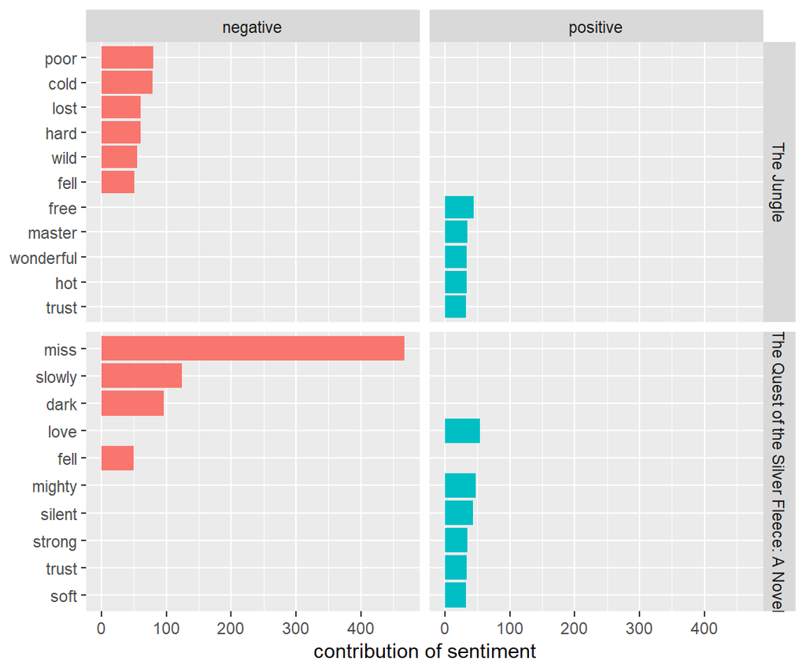

```r
comb_sinclair_Dubiose %>%
  inner_join(get_sentiments("bing"), by = "word") %>%
  count(book, word, sentiment, sort = TRUE) %>%
  group_by(sentiment) %>%
  slice_max(order_by = n, n = 10) %>%
  ungroup() %>%
  mutate(word = reorder(word, n)) %>%
  ggplot(aes(word, n, fill = sentiment)) +
  geom_col(show.legend = FALSE) +
  facet_grid(book ~ sentiment, scales = "free_y") +
  labs(y = "contribution of sentiment", x = NULL) +
  coord_flip()
```

**-** “miss” seems to be inappropriate for the context of the book and should be excluded from the sentiment analysis

9. Remove the inappropriate word(s) from the analysis.
- Replot the top 10 for each sentiment per book from step 8.
- Interpret the plots

```r
get_sentiments("bing") %>%
  filter(word != "miss") ->
bing_no_miss
```

## 1.15

## 1.16

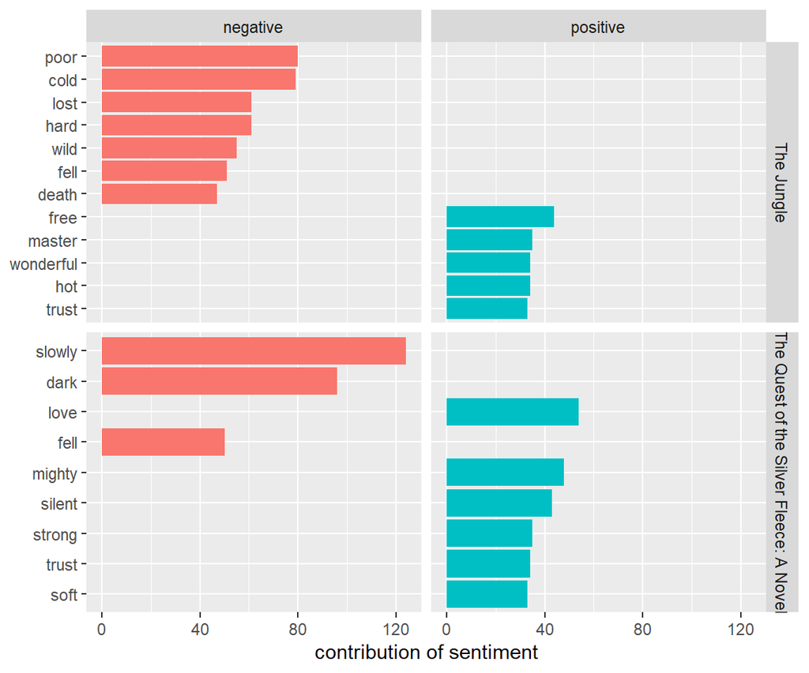

```r
comb_sinclair_Dubiose %>%
  inner_join(bing_no_miss, by = "word") %>%
  count(book, word, sentiment, sort = TRUE) %>%
  group_by(sentiment) %>%
  slice_max(order_by = n, n = 10) %>%
  ungroup() %>%
  mutate(word = reorder(word, n)) %>%
  ggplot(aes(word, n, fill = sentiment)) +
  geom_col(show.legend = FALSE) +
  facet_grid(book ~ sentiment, scales = "free_y") +
  labs(y = "contribution of sentiment", x = NULL) +
  coord_flip()
```

## 1.17

## 1.18

10. Rerun the analysis from step 5 and recreate the plot with the title “Custom Bing”.
- Show both the original step 5 plot with the new plot in the same output graphic, one on top of the other.
- Interpret the plots

## 1.19

## 1.20

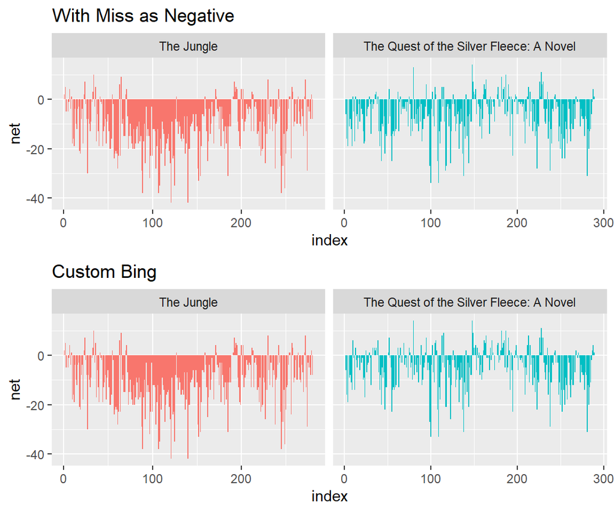

```r
# Original

comb_sinclair_Dubiose %>%
  inner_join(get_sentiments("bing"), by = "word") %>%
  count(book, index = linenumber %/% 50, sentiment) %>%
  pivot_wider(names_from = sentiment, values_from = n, values_fill = list(n=0)) %>%
  mutate(net = positive - negative) ->
  comb_sinclair_Dubiose_sentiment


comb_sinclair_Dubiose %>%
  inner_join(bing_no_miss, by = "word") %>%
  count(book, index = linenumber %/% 50, sentiment) %>%
  pivot_wider(names_from = sentiment, values_from = n, values_fill = list(n=0)) %>%
  mutate(net = positive - negative) ->
  comb_sinclair_Dubiose_sentiment2



comb_sinclair_Dubiose_sentiment %>%
  ggplot(aes(index, net, fill = book)) +
  geom_col(show.legend = FALSE) +
  ggtitle("With Miss as Negative") +
  facet_wrap(~book, ncol = 2, scales = "free_x") ->

  p1


comb_sinclair_Dubiose_sentiment2 %>%
  ggplot(aes(index, net, fill = book)) +
  geom_col(show.legend = FALSE) +
  ggtitle("Custom Bing") +
  facet_wrap(~book, ncol = 2, scales = "free_x") ->

    p2

library(gridExtra)
grid.arrange(p1, p2, nrow =2)
```

**-** The plots are almost identical. The first plots with “miss” reveals large negative comments on both plots and a higher positive comments in the Quest of the silver fleece novel than the Jungle novel. However, when “miss” was removed, It didn’t have much of an effect in the jungle plot because the plot stayed almost the same. But there is a slight change in the positive comments on the Quest of the silver fleece plot especially around the 0-100 range.

## 1.21

## 1.22

# 2 tf-idf for Mark Twain’s books

1. Use a single call to download all the following complete books at once from author Mark Twain from Project Gutenberg
- Use the meta_fields argument to include the Book title as part of the download
- *Huckleberry Finn*, *Tom Sawyer* , *Connecticut Yankee in King Arthur’s Court*, *Life on the Mississippi* , *Prince and the Pauper*, and *A Tramp Abroad*

```r
gutenberg_works() %>%
  filter(author %in% "Twain, Mark",
         title %in% c("A Tramp Abroad",
                      "A Connecticut Yankee in King Arthur's Court",
                      "The Prince and the Pauper",
                      "Life on the Mississippi",
                      "Adventures of Huckleberry Finn",
                      "The Adventures of Tom Sawyer")) %>%
  gutenberg_download(meta_fields = "title") -> mark_twin_books


mark_twin_books
```

```
## # A tibble: 73,688 x 3
##    gutenberg_id text                           title
##           <int> <chr>                          <chr>
##  1           74 "THE ADVENTURES OF TOM SAWYER" The Adventures of Tom Sawyer
##  2           74 ""                             The Adventures of Tom Sawyer
##  3           74 ""                             The Adventures of Tom Sawyer
##  4           74 "By Mark Twain"                The Adventures of Tom Sawyer
##  5           74 ""                             The Adventures of Tom Sawyer
##  6           74 "(Samuel Langhorne Clemens)"   The Adventures of Tom Sawyer
##  7           74 ""                             The Adventures of Tom Sawyer
##  8           74 ""                             The Adventures of Tom Sawyer
##  9           74 ""                             The Adventures of Tom Sawyer
## 10           74 ""                             The Adventures of Tom Sawyer
## # ... with 73,678 more rows
```

2. Modify your earlier function or create a new one to output a tf-idf ready dataframe (**leave the the stop words in the text**)
- Unnest, remove any formatting, and get rid of any `NA`s
- Add the count for each word by title.
- Use your function to tidy the downloaded texts and save to a variable. It should have 56,759 rows.

```r
book_tidy_2 <- function(x) {
  stopifnot(is.tibble(x),
            is.integer(x[[1]]),
            is.character(x[[2]]),
            is.character(x[[3]]))
  x %>%
  unnest_tokens(word, text) %>%
  mutate(word = str_extract(word, "[a-z']+")) %>%
  count(title, word, sort = TRUE) %>%
  filter(!is.na(word))
}

book_tidy_2(mark_twin_books) -> new_book_tidy

new_book_tidy
```

```
## # A tibble: 56,759 x 3
##    title                                       word      n
##    <chr>                                       <chr> <int>
##  1 A Tramp Abroad                              the    9915
##  2 Life on the Mississippi                     the    9175
##  3 Adventures of Huckleberry Finn              and    6374
##  4 A Tramp Abroad                              and    6241
##  5 A Connecticut Yankee in King Arthur's Court the    6091
##  6 Life on the Mississippi                     and    5966
##  7 A Connecticut Yankee in King Arthur's Court and    5551
##  8 Adventures of Huckleberry Finn              the    4913
##  9 A Tramp Abroad                              a      4864
## 10 A Tramp Abroad                              of     4705
## # ... with 56,749 more rows
```

3. Calculate the tf-idf
- Save back to the data frame.

```r
new_book_tidy %>%

  bind_tf_idf(word, title,n) -> new_book_tidy

new_book_tidy
```

```
## # A tibble: 56,759 x 6
##    title                                       word      n     tf   idf tf_idf
##    <chr>                                       <chr> <int>  <dbl> <dbl>  <dbl>
##  1 A Tramp Abroad                              the    9915 0.0622     0      0
##  2 Life on the Mississippi                     the    9175 0.0623     0      0
##  3 Adventures of Huckleberry Finn              and    6374 0.0563     0      0
##  4 A Tramp Abroad                              and    6241 0.0392     0      0
##  5 A Connecticut Yankee in King Arthur's Court the    6091 0.0511     0      0
##  6 Life on the Mississippi                     and    5966 0.0405     0      0
##  7 A Connecticut Yankee in King Arthur's Court and    5551 0.0466     0      0
##  8 Adventures of Huckleberry Finn              the    4913 0.0434     0      0
##  9 A Tramp Abroad                              a      4864 0.0305     0      0
## 10 A Tramp Abroad                              of     4705 0.0295     0      0
## # ... with 56,749 more rows
```

4. Plot the tf for each book using a faceted graph.
- Facet by book and constrain the data or the X axis to see the shape of the distribution.

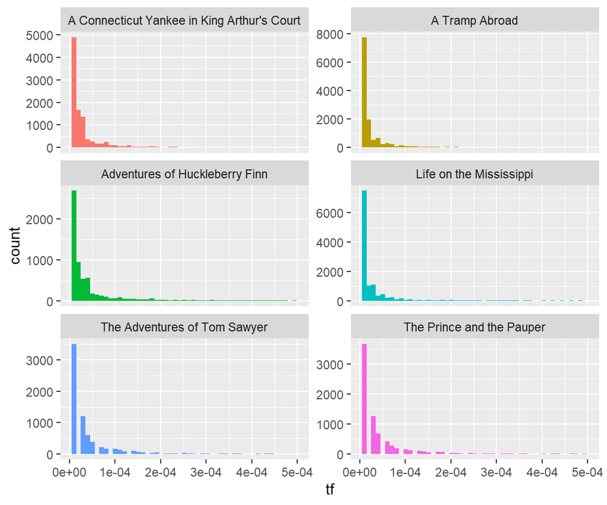

```r
new_book_tidy %>%
  ggplot(aes(x = tf, fill = title)) +
  geom_histogram(show.legend = FALSE, bins = 50) +
  xlim(NA, 0.0005) +
  facet_wrap(~title, ncol = 2, scales = "free_y")
```

5. Show the words with the 15 highest tf-idfs across across all books
- Only show those rows.
- How many look like possible names?

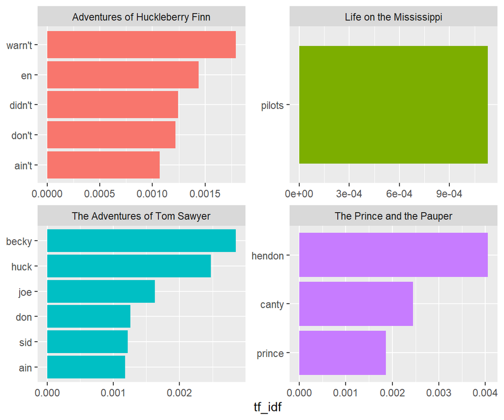

```r
new_book_tidy %>%
  top_n(15, tf_idf) %>%
  mutate(word = fct_reorder(word, tf_idf)) %>%
  ggplot(aes(x = word, y = tf_idf, fill = title)) +
  geom_col(show.legend = FALSE) +
  labs(x = NULL, y = "tf_idf") +
  facet_wrap(~title, ncol = 2, scales = "free") +
  coord_flip()
```

**-**The Adventure of Tom Sawyer and the Prince and the Pauper names look like possible names with names like becky, huck, joe, don, sid, hendon, canty, prince.

6. Plot the top 7 tf_idf words from each book.
- Sort in descending order of tf_idf
- Interpret the plots.

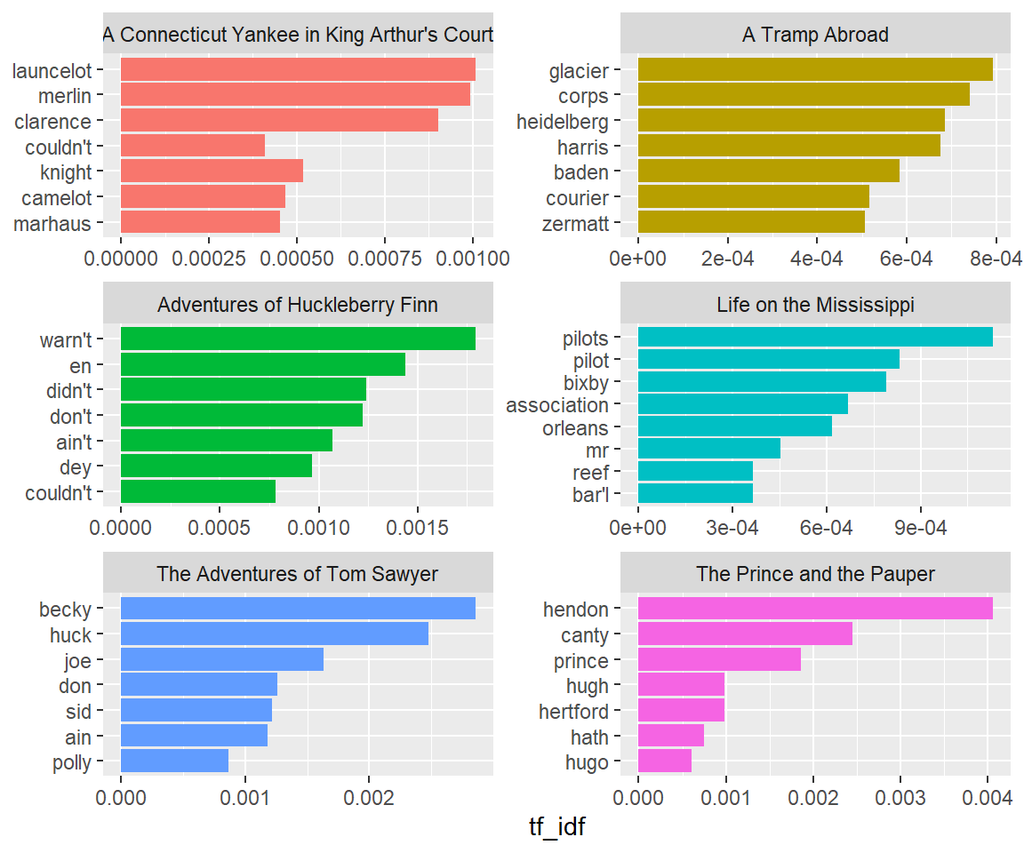

```r
new_book_tidy %>%
  group_by(title) %>%
  top_n(7, tf_idf) %>%
  ungroup() %>%
  mutate(word = fct_reorder(word, tf_idf)) %>%
  ggplot(aes(x = word, y = tf_idf, fill = title)) +
  geom_col(show.legend = FALSE) +
  labs(x = NULL, y = "tf_idf") +
  facet_wrap(~title, ncol = 2, scales = "free") +
  coord_flip()
```

# 3 Extra Credit Podcasts

- Choose **One** of the following podcasts and answer the questions below:
1. [Sentiment Preserving Fake Reviews](https://podcasts.apple.com/us/podcast/data-skeptic/id890348705?i=1000483067378)  
   The [Original paper](https://arxiv.org/abs/1907.09177)
2. [Data in Life: Authorship Attribution in Lennon-McCartney Songs](https://podcasts.apple.com/us/podcast/authorship-attribution-of-lennon-mccartney-songs/id890348705?i=1000485519404)

## 3.1 Ans: Sentiment Preserving Fake Reviews.

1. What are some key ideas from this podcast relevant to text sentiment analysis/authorship attribution?

**-** One of key ideas that is relevant to text sentiment analysis is the importance of building a model and a system that helps in distinguishing between fake reviews and real reviews. It is increasingly more difficult to tell a fake reviews than tell a real review. From the statistics presented by the guest speaker, only 25% of their sample analysis was able to accurately identify real reviews from the fake reviews. This is a big problem and suggest that the level of misinformation that people are exposed to.

2. How do you think the ideas discussed may be relevant in your future work? **-** The ideas will be useful in the sense that one has to properly analyze the content of the sentiments and their credibility of the user who provides this information and also have a system that guides user which which enable human detect fake reviews. It is also important to analyze story and not text. This also helps in identifying fake reviews.